# Raport z pracy domowej nr 3

Mazuryk Michał, Matuszewski Szymon, Kosiuk Wojciech

20-11-2021

# Praca domowa 3

## Wstęp

Niniejszy raport został stworzony na potrzeby pracy domowej 3 z przedmiotu Techniki Wizualizacji Danych. Celem pracy domowej było sprawdzenie czy w społeczeństwie występują problemy z odczytywaniem danych z wykresów.

## 1. Badanie wpływu kolorów na odbiór wykresów

Badanie miało na celu sprawdzenie w jakim stopniu błędnie dobrane kolory na wykresie wpływają na nieprawidłowy odczyt danych. W tym celu została sporządzona ankieta z czterema zadaniami, w których zastosowano kolejno:

- tęczową paletę barw na mapie
- intensywność kolorów dominujących lub niedominujących
- różnorodność kompozycji barw na zwykłym wykresie słupkowym
- skalę z nieintuicyjnymi kolorami.

W badaniu brały udział 23 osoby.

**Uwaga**: Odpowiedzi, które są poprawne będą zaznaczone na niebiesko.

### Zadanie 1

Zadanie 1 polegało na prostej analizie mapy przedstawiającej dane uśrednionej emisji dwutlenku węgla w przeliczeniu na kilometr samochodów rejestrowanych w danych państwach w 2020 roku. Oto treść ogólna zadania:

> Przed Tobą mapa Europy, która przedstawia dane uśrednionej emisji dwutlenku węgla w przeliczeniu na kilometr samochodów rejestrowanych w danych państwach w 2020 roku. Oceń, czy zdania są prawdziwe:

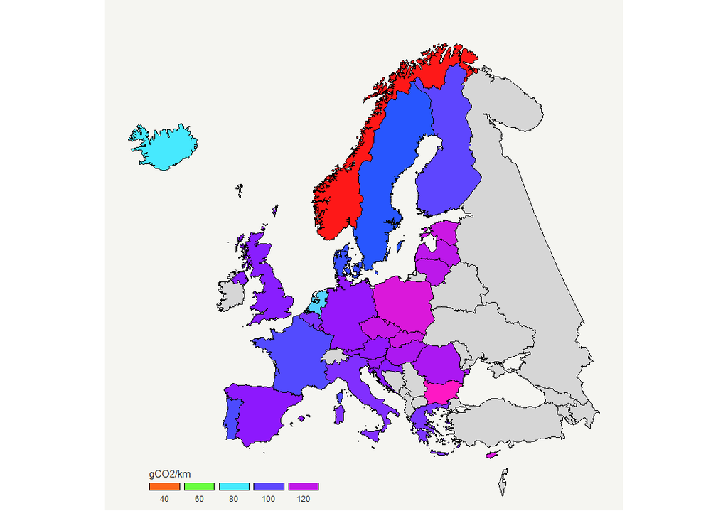

Mapa do 1. zadania

#### Pytania i odpowiedzi

Pytanie A:

> Samochody rejestrowane w Polsce w 2020 produkują średnio mniej dwutlenku węgla niż samochody z Francji.

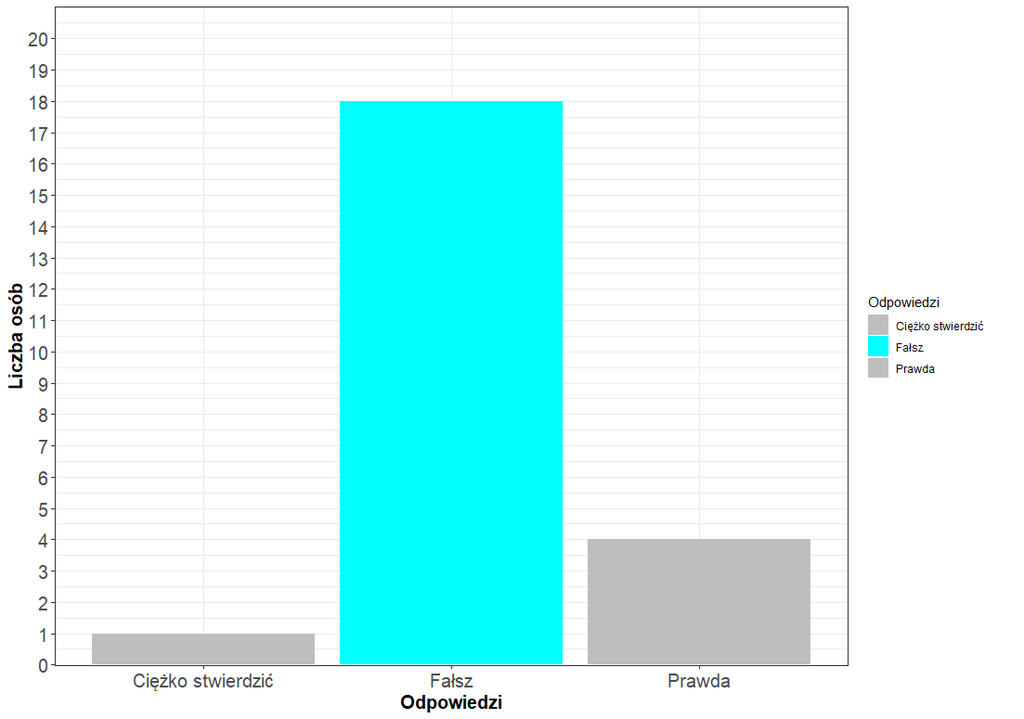

Odpowiedzi do pytania 1.A

Pytanie B:

> Norwegia prezentuje się najgorzej w danym zestawieniu.

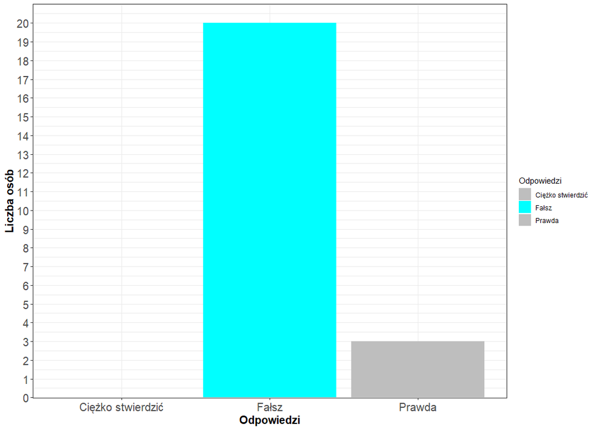

Odpowiedzi do pytania 1.B

Pytanie C:

> Podaj państwo, w którym samochody z 2020 roku emitują najmniej dwutlenku węgla:

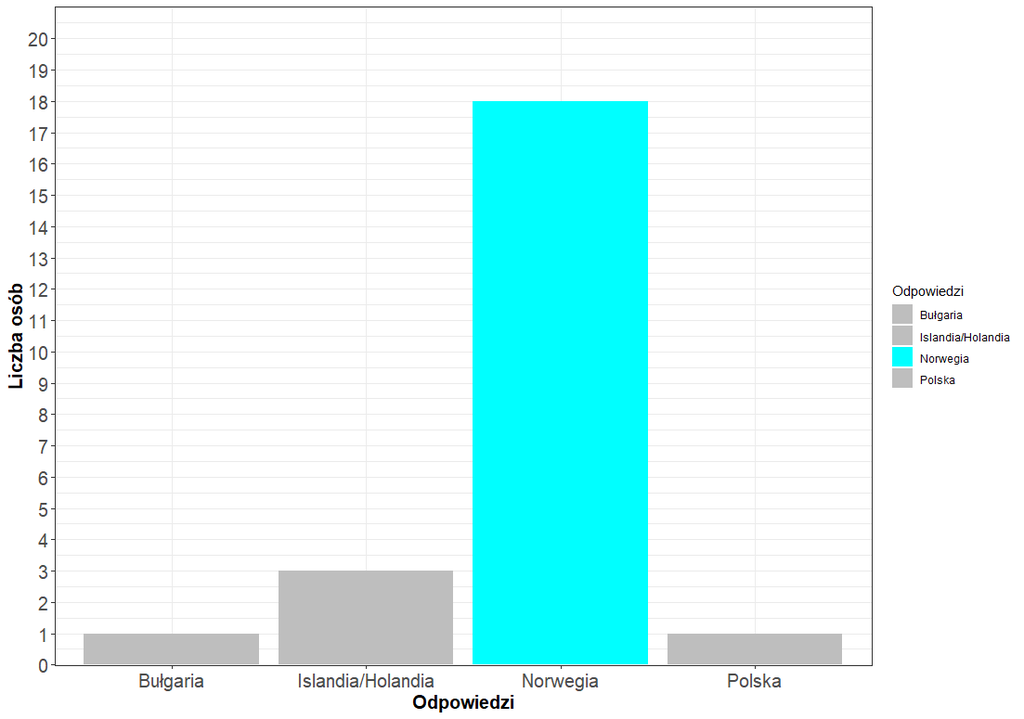

Odpowiedzi do pytania 1.C

#### Wnioski

Stosowanie palety barw ze znacznie odbiegającymi od siebie kolorami na wykresie może sprawić, że wnioski wyciągane przez czytelnika będą nie takie, jakie sobie założymy jako twórcy. Najciekawszym dowodem na to stwierdzenie jest fakt, że troje ankietowanych w ostatnim podpunkcie z tego zadania wskazało Islandię lub Holandię jako państwa z najmniejszą emisją dwutlenku węgla przez samochody, mimo że państwa te oznaczone są kolorem środkowym w użytej skali. Jak widać, niektórzy patrzą jedynie na kolory nie czytając wcześniej legendy.

### Zadanie 2

Zadanie 2 polegało na szybkiej analizie dwóch wykresów kropkowych zestawionych obok siebie. W zadaniu tym legenda nie była istotna - ankietowani nie mieli do niej dostępu. W rzeczywistości oba wykresy były tym samym wykresem, wykres B powstał z wykresu A poprzez usunięcie jednego kontyntnentu, zamianę kolorów oraz odwrócenie osi. Oto treść zadania:

> Przed Tobą dwa wykresy przedstawiające współczynnik zgonów i urodzeń dla państw podzielonych według kontynentów.

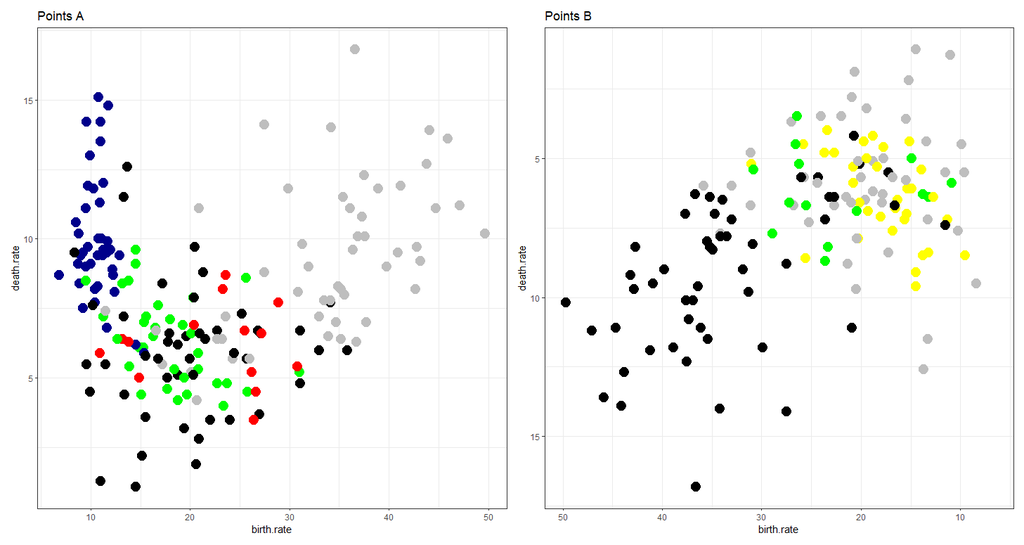

Wykresy do 2. zadania

#### Pytania i odpowiedzi

Pytanie A:

> Najliczniejszą grupą na wykresie A są kropki:

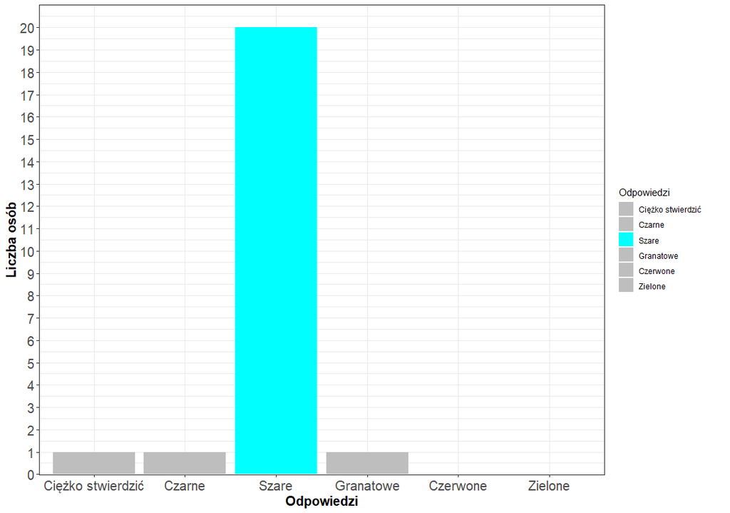

Odpowiedzi do pytania 2.A

Pytanie B:

> Najliczniejszą grupą na wykresie B są kropki:

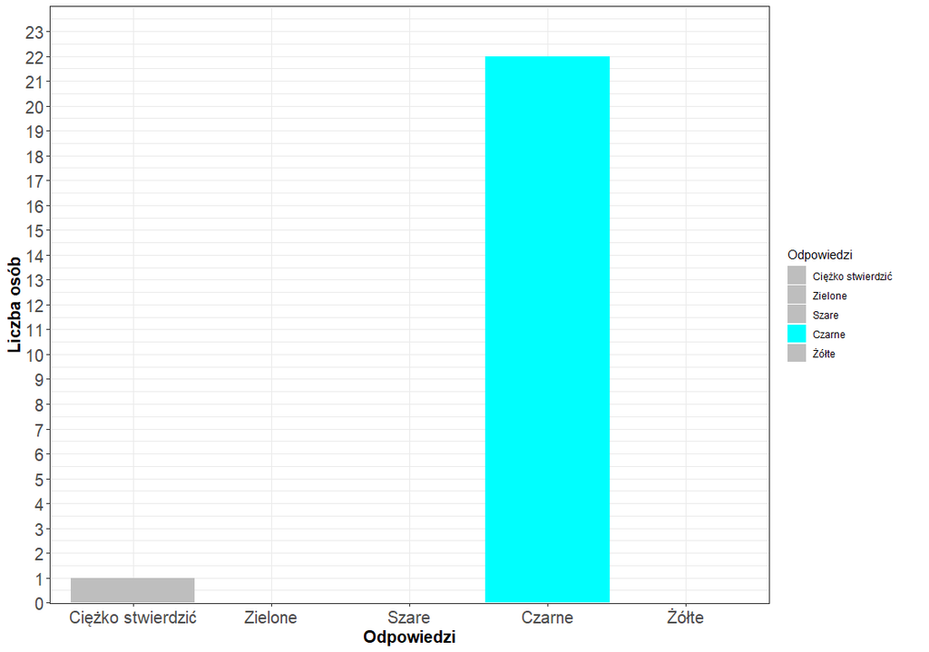

Odpowiedzi do zadania 2.B

Pytanie C:

> Kropek szarych na wykresie A jest ____ niż kropek czarnych na wykresie B.

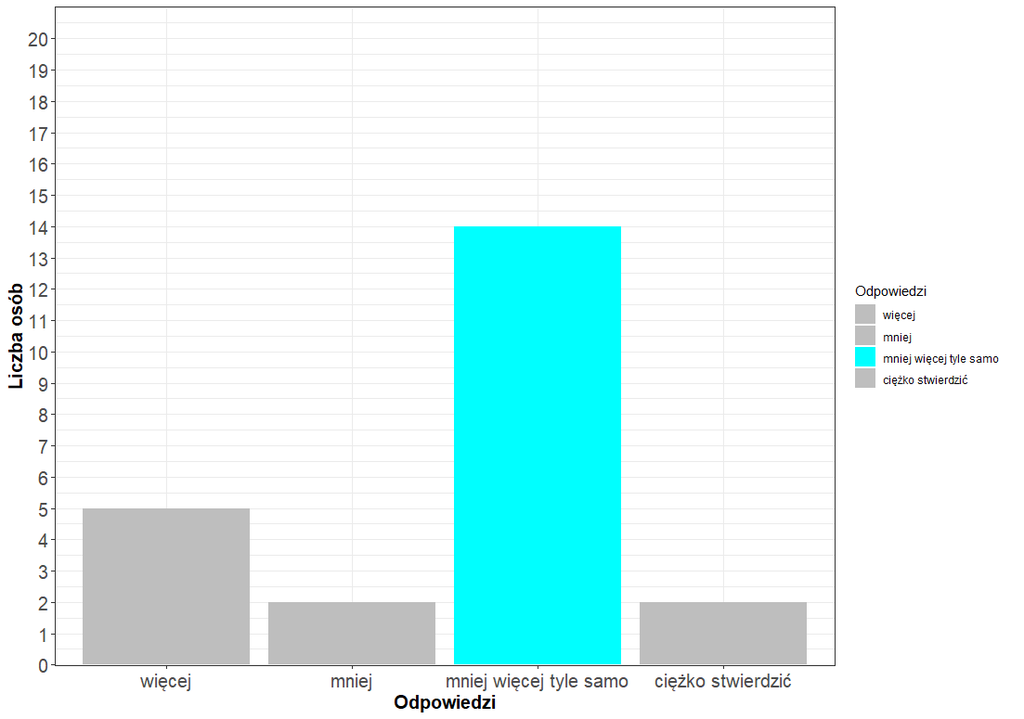

Odpowiedzi do zadania 2.C

#### Wnioski

W obrębie jednego wykresu łatwo można określić, który kolor jest dominujący niezależnie od jego nasycenia - ankietowani bez problemów odgadywali, że więcej jest kropek szarych od czarnych i na odwrót. Drobne kłopoty pojawiają się, gdy obok znajduje się inny wykres z podobnymi kolorami, jednak inaczej usegregowanymi (nawet, gdy wykresy są tym samym wykresem).

### Zadanie 3

Zadanie 3 polegało na udzieleniu subiektywnej opinii nt. kolorów użytych w wykresach słupkowych. Oto treść zadania:

> Przed Tobą 6 wykresów obrazujących liczbę państw w Europie na tle innych kontynentów. Odpowiedz, jak uważasz.

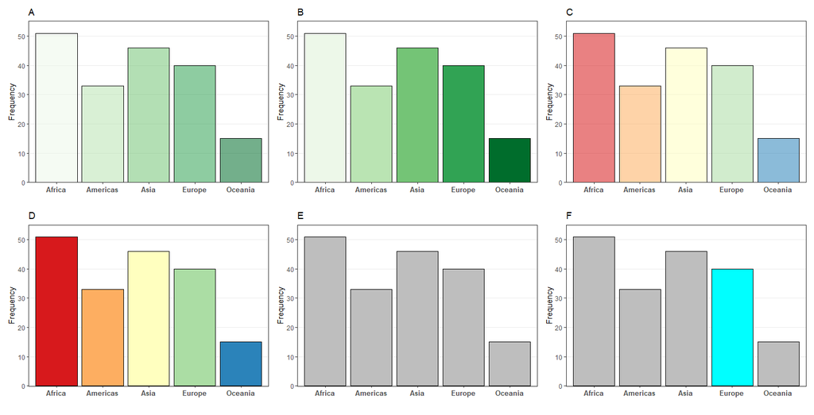

Wykresy do 3. zadania

#### Pytania i odpowiedzi

Pytanie A:

> Moim zdaniem dane zagadnienie najlepiej obrazuje wykres:

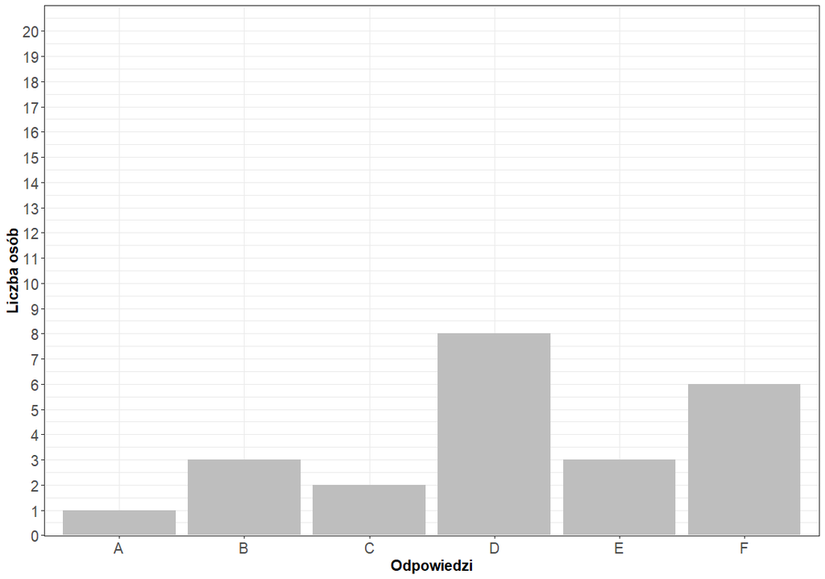

Odpowiedzi do zadania 3.A

Pytanie B:

> Gdybym sam/-a miał/-a utworzyć taki wykres wybrałbym wykres:

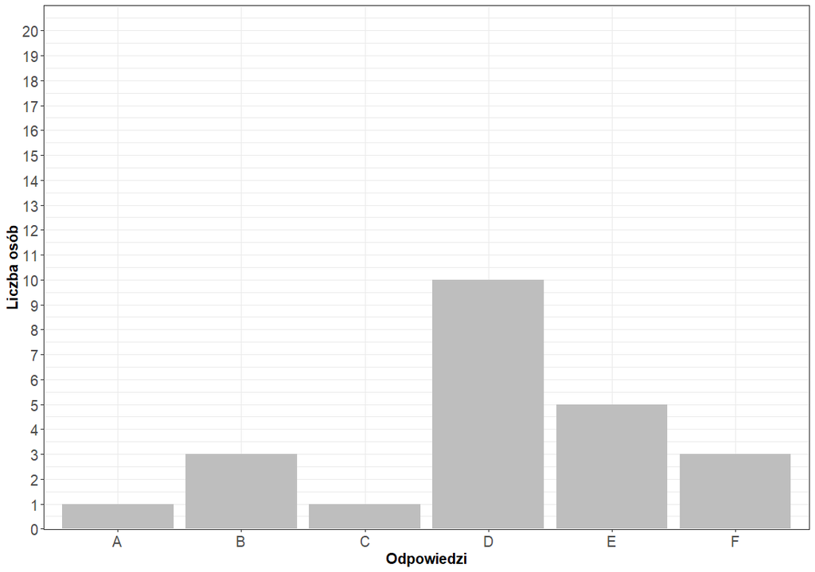

Odpowiedzi do zadania 3.B

#### Wnioski

Możemy zauważyć, że kolory na wykresie są dla ludzi istotne. W swoich wykresach użyliby niepotrzebnie intensywnej palety barw, które niczego do wykresu nie wnoszą. Niepokoi fakt, że spora część ankietowanych uważa, że wykres F najlepiej obrazuje dane zagadnienie (słuszny wybór, gdyż tylko Europa jest zaznaczona na wyróżniający się kolor), ale potem tylko 3 osoby użyłyby tego wykresu, gdyby same miały robić taki wykres. Nasuwa się poważny wniosek: ludzie zadowalają się kolorowym obrazkiem a nie interesują się za bardzo jakie informacje on przekazuje.

### Zadanie 4

Zadanie 4 polegało na prostej analizie heatmapy, na której zastosowano niestandardową skalę - kolor czerwony oznaczał 100%, kolor zielony 0%. Tym razem ankietowani mieli dostęp do skali. Oto treść zadania:

> W pewnej klasie przeprowadzono egzaminy z 4 przedmiotów: biologii, informatyki, fizyki i matematyki. Na danym wykresie widzimy jak radzili sobie trzej uczniowie: Alan, Ben oraz Cody. Wyniki z egzaminów podane były w procentach. Odpowiedz na pytania.

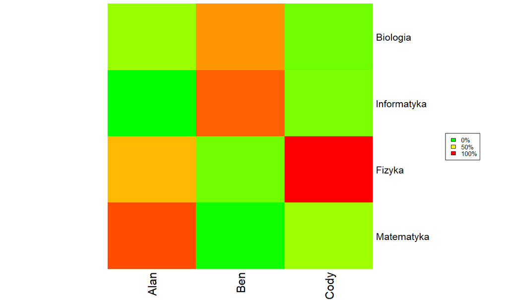

Wykres do 4. zadania

#### Pytania i odpowiedzi

Pytanie A:

> Który chłopiec napisał najgorzej egzamin z fizyki?

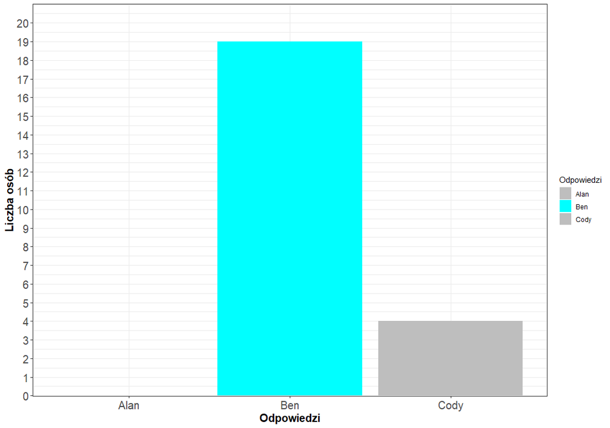

Odpowiedzi do zadania 4.A

Pytanie B:

> Benowi nie poszło najlepiej z informatyki.

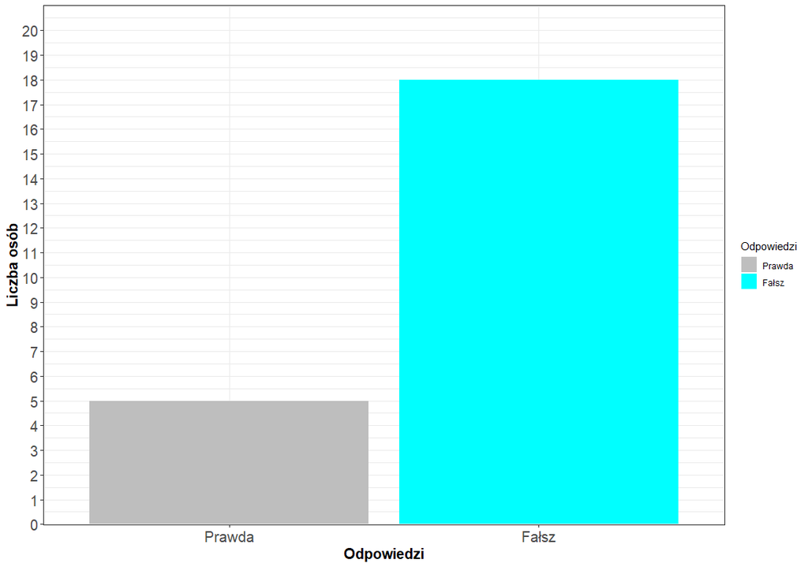

Odpowiedzi do zadania 4.B

Pytanie C:

> Możemy powiedzieć, że Alan jest lepszy z matematyki niż fizyki.

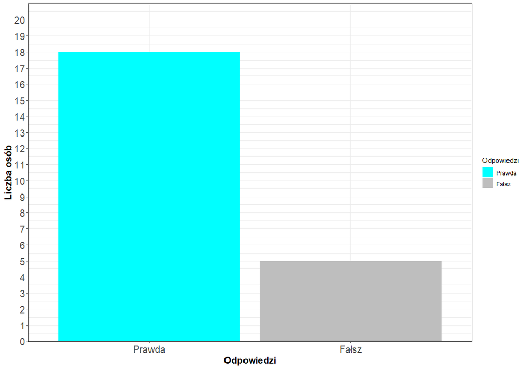

Odpowiedzi do zadania 4.C

#### Wnioski

Około 20% ludzi oglądając wykres nie patrzy na legendę i kieruję się ogólnie przyjętymi zasadami odczytu kolorów (w przypadku tego zadania: czerwony - źle, zielone - dobrze). W związku z tym bardzo ważne jest, aby kolory do wykresu wybierać zgodnie z tymi, które są intuicyjne w odbiorze.

### Podsumowanie badania

Kwestie odpowiedniego dobrania kolorów do wykresu (lub zrezygnowanie z nich) są szczególnie istotne dla właściwego odbioru wykresu. Niestety ludzie wydają się być nie do końca świadomi tego faktu i często kierują się wyłącznie aspektem estetycznym. Owszem jest on ważny, ale tworząc wykres należy zadać sobie pytanie: w pierwszej kolejności chcę aby mój wykres został dobrze odczytany, czy może chcę wywołać tylko efekt ‘wow’? Oczywiście jedno nie wyklucza drugiego, ale na samym początku najlepiej zadbać o treść, a dopiero potem zająć się ozdobnikami. Przy doborze kolorów warto też pamiętać, że czasami (a nawet najczęściej) prostota jest najlepszym rozwiązaniem. Przesyt kolorów może zniweczyć cały nasz wysiłek włożony w poprawne przedstawienie treści. Z powyższego badania można wyciągnąć 3 rady w doborze kolorów:

- Czasami im mniej tym lepiej
- Trzymaj się konwencji
- Jeśli nie wiesz po co kolorujesz, po prostu tego nie rób.

## 2. Badanie wpływu złożoności wykresu na czas jego zrozumienia

Badanie miało na celu sprawdzenie czy odbiorca szybciej odczyta wykres bardziej skomplikowany, czy parę wykresów odpowiadających jego treści. Stosowanie wielu oznaczeń na jednym skomplikowanym wykresie może przyspieszyć jego ogólne zrozumienie, ale spowolnić, jak i utrudnić odczytanie informacji. Użycie zamiast niego kilku prostszych wykresów przedstawiających te same dane może za to przyspieszyć odczytanie, ale wydłużyć czas potrzebny na zrozumienie. W celu sprawdzenia, która z tych opcji jest lepsza zostały sporządzone 2 ankiety, jedna ze skondensowanymi wykresami, a druga z ich prostymi odpowiednikami. W obu był mierzony czas.

W badaniu brało udział 18 osób.

**Uwaga**: Odpowiedzi, które są poprawne będą zaznaczone na niebiesko.

### Formularz 1 - zadanie 1

Zadanie 1 sprawdzało czy przy zbyt wielu informacjach na wykresie odbiorcy są w stanie skupić się tylko na potrzebnych danych do odczytu, czy może ta ilość informacji uniemożliwi im głębsze wczytanie. Oto treść zadania:

> Wykres przedstawia zależności wskaźnika urodzeń w zależności od wskaźnika zgonów w wybranych krajach podzielonych pod względem ich wielkości:

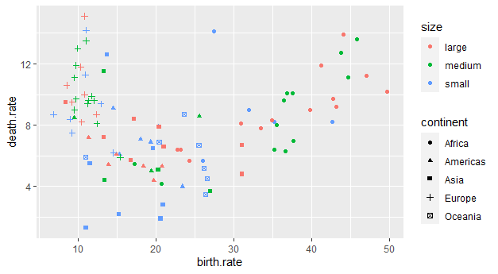

Wykres do 1. zadania

#### Pytania i odpowiedzi

Pytanie A:

> Na którym kontynencie znajduje się kraj z najwyższym współczynnikiem zgonów?

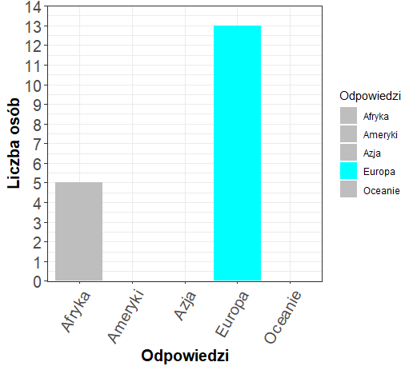

Pytanie B:

> Jakiej wielkości kraje w Afryce mają najniższy średni współczynnik urodzeń?

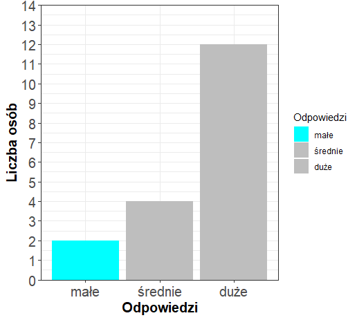

Pytanie C:

> Na którym kontynencie przeważają procentowo państwa małe?

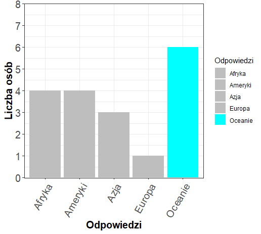

Odpowiedzi do pytania 1.C

### Formularz 2 - zadanie 1

Jest to odpowiednik zadania 1. z podobnymi pytaniami, ale wykres jest rozbity na prostsze.

> Wykres przedstawia zależności wskaźnika urodzeń w zależności od wskaźnika zgonów w wybranych krajach podzielonych pod względem ich wielkości:

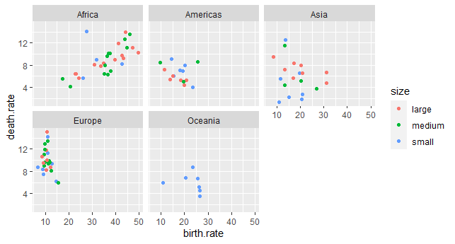

Wykres do 1. zadania

#### Pytania i odpowiedzi

Pytanie A:

> Na którym kontynencie znajduje się kraj z najwyższym współczynnikiem urodzeń?

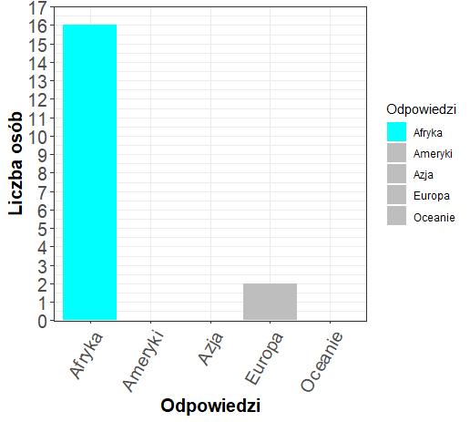

Pytanie B:

> Jakiej wielkości kraje w Azji mają najwyższy średni współczynnik zgonów?

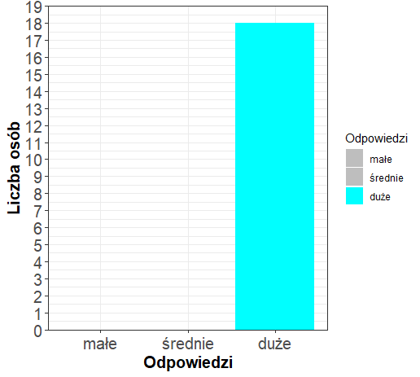

Pytanie C:

> Na którym kontynencie przeważają procentowo państwa średniej wielkości?

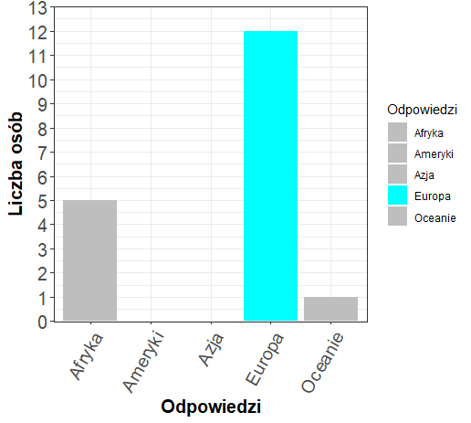

### Formularz 1 - zadanie 2

Zadanie 2 skupiało się na porównywaniu między sobą wartości przedstawionych na wykresie.

> Wykres przedstawia ilość sprzedanych pojazdów producenta X w zależności od miejsca sprzedaży i rodzaju pojazdu:

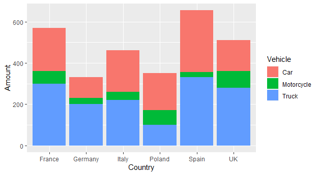

Wykres do 2. zadania

#### Pytania i odpowiedzi

Pytanie A:

> Najwięcej razem producent X sprzedał:

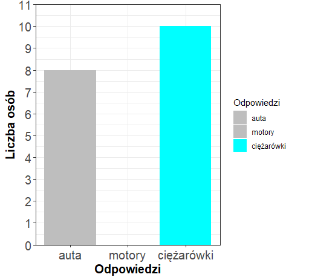

Pytanie B:

> W którym kraju sprzedano najmniej motorów?

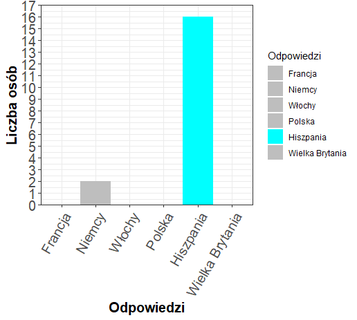

Pytanie C:

> Jakiego typu pojazdów sprzedano w Hiszpanii najwięcej?

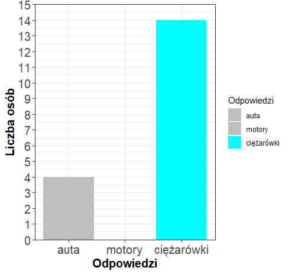

### Formularz 2 - zadanie 2

Odpowiada zadaniu 2. z formularza 1.

> Wykres przedstawia ilość sprzedanych pojazdów producenta X w zależności od miejsca sprzedaży i rodzaju pojazdu:

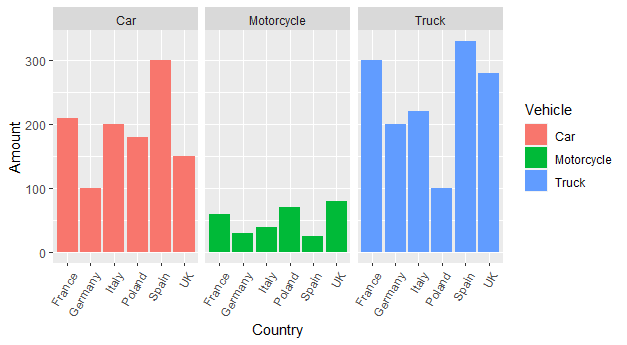

Wykres do 2. zadania

#### Pytania i odpowiedzi

Pytanie A:

> Najmniej razem producent X sprzedał:

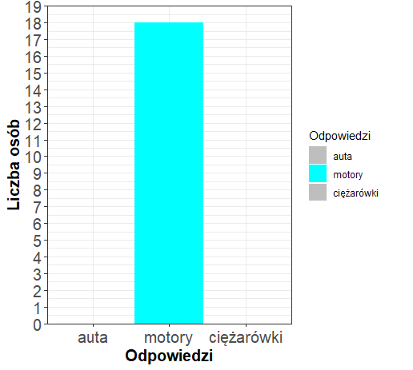

Pytanie B:

> W którym kraju sprzedano najwięcej ciężarówek?

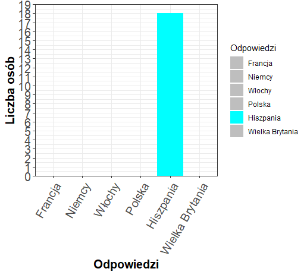

Pytanie C:

> Jakiego typu pojazdów sprzedano w Polsce najwięcej?

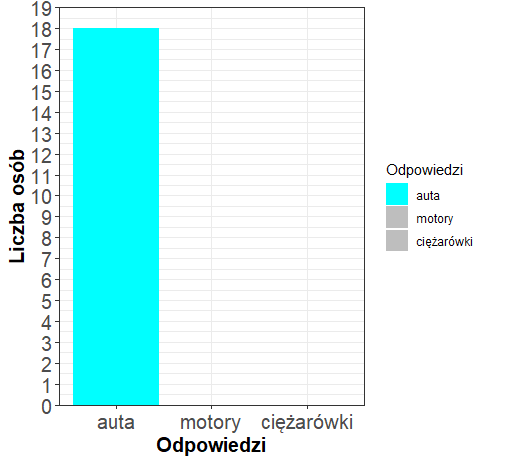

Odpowiedzi do pytania 2.C

### Podsumowanie badania

Wykres czasu wykonania formularzy prezentuje się następująco:

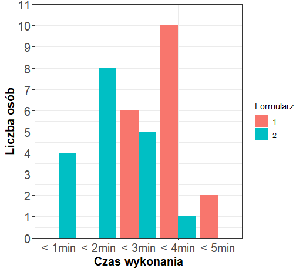

Odczytywanie kilku wykresów prostszych zajęło odbiorcom średnio mniej czasu niż jednego, bardziej skomplikowanego. Okazuje się, że czas, w którym następuje ogólne zrozumienie wykresu jest dla obu przypadków porównywalny, za to samo znajdowanie i porównywanie poszczególnych wartości w 2. przypadku jest łatwiejsze. Wpływa to również na poprawność wykonywania zadań, czyli lepsze zrozumienie danych. Oznacza to, że przy dużej ilości danych do wizualizacji nie musimy starać się przedstawić wszystkiego na jednym wykresie, ale skorzystać z kilku dodatkowych, ponieważ może to poprawić szybkość zrozumienia i odczytania informacji przez odbiorców.